# 5. házi

#Alapkérdés a 4. háziból: hatékonyabb-e egy agresszívabb hoki játékos az NHL-ben? A feltevésünk, hogy az aggresszívabb játékosok kevésbé hatékonyak. #Az aggresszivitás nem mért mennyiség, de a kiállítások száma (PIM - Penalty in minutes) lehet a mércéje, mert a kiállítások száma utalhat agresszivitásra. #Egy játékos hatékonyságát a PTS változóval mérjük, ami a belőtt gólok és a gólpasszok összegét jelenti. #Mi a PTS változót fogjuk PIM különböző hatványaival regresszálni és ezeknek ha hibáit vizsgáljuk meg.

#A megoldást innentől angolul írjuk.

#Set up data and others

```r
library(data.table)
library(ggplot2)
library(purrr)
library(caret)
skater <- fread("data/clean_nhl.csv")
skater <- skater[Pos=='C']
```

#Create splitting indices for train, test and cross-validation

```r
n <- skater[,.N,]
fold <- 7
cv_split <- split(sample(1:n), 1:fold)
train_split <- split(sample(1:n), 1:fold)[1]
```

#Create candidate models with increasing complexity

```r
complexity_levels <- 8
formula_strings <- c() # vector that will contain all formulas
for (i in c(1:complexity_levels)) { # with the help of this loop we fill up the formula list
  formula_single <- c("PTS ~ ")
  for (j in c(1:i)) {
  addtext <- paste("+ I(PIM^",toString(j),") ",sep = "")
    formula_single <- paste(formula_single,addtext, sep = "", collapse = NULL)
  }
  formula_strings <- c(formula_strings,formula_single)
}
formula_strings
```

```
## [1] "PTS ~ + I(PIM^1) "
## [2] "PTS ~ + I(PIM^1) + I(PIM^2) "
## [3] "PTS ~ + I(PIM^1) + I(PIM^2) + I(PIM^3) "
## [4] "PTS ~ + I(PIM^1) + I(PIM^2) + I(PIM^3) + I(PIM^4) "
## [5] "PTS ~ + I(PIM^1) + I(PIM^2) + I(PIM^3) + I(PIM^4) + I(PIM^5) "
## [6] "PTS ~ + I(PIM^1) + I(PIM^2) + I(PIM^3) + I(PIM^4) + I(PIM^5) + I(PIM^6) "
## [7] "PTS ~ + I(PIM^1) + I(PIM^2) + I(PIM^3) + I(PIM^4) + I(PIM^5) + I(PIM^6) + I(PIM^7) "
## [8] "PTS ~ + I(PIM^1) + I(PIM^2) + I(PIM^3) + I(PIM^4) + I(PIM^5) + I(PIM^6) + I(PIM^7) + I(PIM^8) "
```

```r
# Create empty vectors that will store the 3 types of calculated errors for each model complexity level
train_errors <-c()
test_errors <-c()
cv_errors <-c()

# Go through every complexity level in a for loop
for(formula_string in formula_strings){
formula <- as.formula(formula_string)

# Calculate error for train data set for current level of model complexity
train_error_list <- map(train_split, ~{
  model <- lm(formula = formula, data = skater[-.x,])
  p <- predict(model, newdata = skater[-.x,])
  mean((p - skater[-.x, PTS])^2)
})
train_error <- train_error_list[1]

# Calculate error for test data set for current level of model complexity
test_error_list <- map(train_split, ~{
  model <- lm(formula = formula, data = skater[-.x,])
  p <- predict(model, newdata = skater[.x,])
  mean((p - skater[.x, PTS])^2)
})
test_error <- test_error_list[1]

# Calculate error of cross-validation for current level of model complexity
cv_error_list <- map(cv_split, ~{
  model <- lm(formula = formula, data = skater[-.x,])
  p <- predict(model, newdata = skater[.x,])
  mean((p - skater[.x, PTS])^2)
})
cv_error <- mean(unlist(cv_error_list))

# Append all 3 errors to lists in order to save them for later
train_errors <-c(train_errors,train_error)
test_errors <-c(test_errors,test_error)
cv_errors <-c(cv_errors,cv_error)

}
# End of for loop

#Construct data table from the error results
complexity_errors <- data.table(train = train_errors, test = test_errors, cv = cv_errors)
```

#Plot the resulting errors

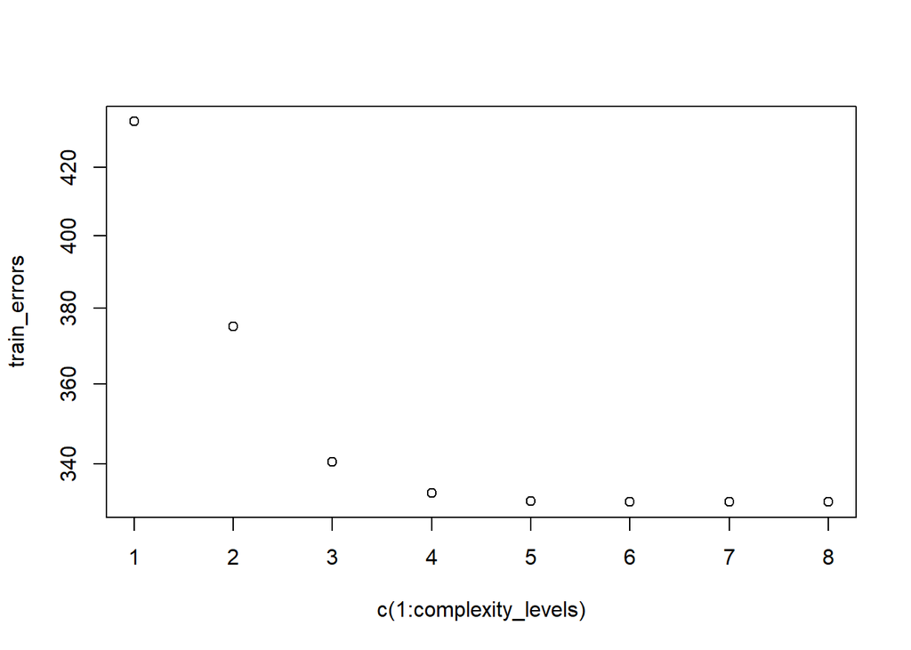

```r
plot(c(1:complexity_levels),train_errors, log = "y")
```

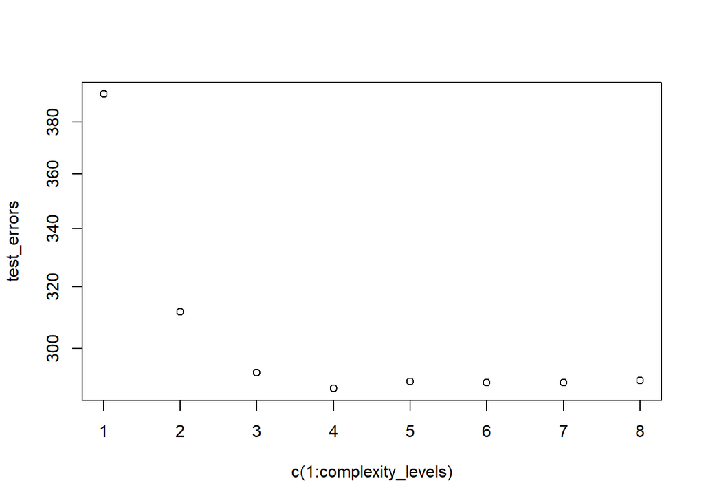

```r
plot(c(1:complexity_levels),test_errors, log = "y")
```

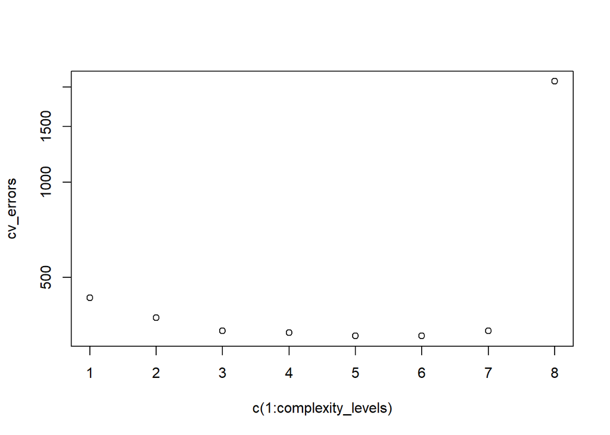

```r
plot(c(1:complexity_levels),cv_errors, log = "y")
```

#Conclusion from errors: #We have ran the full analysis with several random splittings for each of the tests. They are giving different results for optimal complexity, but it is usually between 3 and 6 #From there results we decided to choose a middle ground of complexity level 4. Thus the best model formula is: PTS ~ + I(PIM^1) + I(PIM^2) + I(PIM^3) + I(PIM^4)